# 4.2 Aggregate demand prediction with feature models

## 4.2.1. Introduction

We will predict the aggregate demand using the features engineered Section 4.1 (using Python). We will apply linear models and, depending on the accuracy of the prediction, we may try other algorithms. It is worth reminding that dedicated time series modelling, namely exponential smoothing, will be applied in the next section.

We will start with Ordinary Least Squares and then regularised linear regression: Lasso and Ridge.

Our target variable (y) is mean_cons: the mean consumption in kWh/30min. The predictors are: -13 derived features (based on previous consumption data). -Day of week (7 levels) -Holiday (binary) -4 weather variables (Temperature, Relative humidity, Atmospheric pressure, Cloud cover). The last two are an indirect measure of the precipitation (which is not available) and general weather conditions. -Tariff

The month was not included as only one year of ToU data is available so not all months will be available for ToU users in neither the train nor the test sets. Furthermore, it would add a categorical variable with 12 levels and other variables account for monthly effects (weather data and the derived features).

The time series can be broken down in two: Standard flat rate users (all users in 2011, 2012 and 2014 and those not subjected to ToU in 2013) and ToU users (only in 2013). This means that a presumably important predict, which is the tariff value, only influences ToU users.

One approach could be to do separate models for standard and ToU users, but we will do one model for both. Moreover, the tariff price is a numerical value in nature, but it is not a continuous variables, as it takes only 3 possible levels in ToU and another 1 different constant level in the standard tariff. To take into account both effects, we will first try an Ordinary Least Sqaures (OLS) considering the tariff as a numerical variable but only for ToU consumers (by including in the model only the interaction between tariff value and a binary variable whose value is 1 when the user is subject to ToU). Then, we will consider the tariff as a categorical variable with 4 levels, thus making the difference between standard and ToU users and the 3 different possible tariff values.

## 4.2.2. Data preparation

The data has already been processed but we need a few changes to use it in our models.

First, let us download the data and parse the DateTime column to the appropriate format. We also drop some variables not needed in the feature models nor for processing.

```r
df <- read.csv('outputs/features_model.csv')
df$DateTime <- as.POSIXct(df$DateTime, tz= "GMT", format = "%Y-%m-%d %H:%M:%S")
df <- subset(df, select = -c(Date,Year,Month,sum,count))
head(df)
```

```
##              DateTime Tariff_value mean_cons ToU Holiday temperature
## 1 2011-11-24 09:00:00       14.228 0.1631538   0       0       10.09
## 2 2011-11-24 09:30:00       14.228 0.1691429   0       0       10.09
## 3 2011-11-24 10:00:00       14.228 0.2201875   0       0       11.01
## 4 2011-11-24 10:30:00       14.228 0.2034118   0       0       11.01
## 5 2011-11-24 11:00:00       14.228 0.1972778   0       0       12.33
## 6 2011-11-24 11:30:00       14.228 0.1848889   0       0       12.33
##   humidity cloudCover pressure   Set      DoW Time mean_prev_day
## 1     0.95       0.54  1029.00 Train Thursday  9.0     0.2639143
## 2     0.95       0.54  1029.00 Train Thursday  9.5     0.2639143
## 3     0.93       0.53  1028.98 Train Thursday 10.0     0.2639143
## 4     0.93       0.53  1028.98 Train Thursday 10.5     0.2639143
## 5     0.88       0.51  1028.42 Train Thursday 11.0     0.2639143
## 6     0.88       0.51  1028.42 Train Thursday 11.5     0.2639143
##   mean_cons_.1380 mean_cons_.1410 mean_cons_.1440 mean_last3d_.0
```

[output cut: 20 more lines]

## 4.2.3. Linear models

First, we can calculate the naïve predictor: the mean of the response value. We do it for the whole dataset and for standard and ToU separately as we are also interested in knowing how good the models are to predict ToU users aggregate demand.

```r
y.std.mean <- mean(df[df["ToU"] == 0,"mean_cons"])
y.ToU.mean <- mean(df[df["ToU"] == 1,"mean_cons"])
y.mean <- mean(df$mean_cons)
```

### Ordinary Least Squares

Now we will fit an Ordinary Leasts Squares model to the train dataset.

```r
ols <- lm(mean_cons ~ Tariff_value:ToU + Holiday + temperature + humidity + cloudCover + pressure + DoW + Time  + mean_prev_day +
            + mean_cons_.1380 + mean_cons_.1410 + mean_cons_.1440 + mean_last3d_.0 + mean_last3d_.30 + mean_last3d_.60 +
            + mean_last3d_.90 + mean_last3w_.0 + mean_last3w_.30 + mean_last3w_.60 + mean_last3w_.90, data = subset(df, Set == "Train"))
pred.ols <- predict.lm(ols, newdata = subset(df, Set == "Test", select = -c(Set,mean_cons)))
rmse.ols <- mean((pred.ols - df[df["Set"] == "Test", "mean_cons"])^2)^(1/2)
```

The normalised RMSE in the test data is:

```r
rmse.ols/y.mean
```

```
## [1] 0.08601405
```

And for ToU data only it is:

```r
pred.ToU.ols <- predict.lm(ols, newdata = df[df["Set"] == "Test" & df["ToU"] == 1,])
rmse.ToU.ols <- mean((pred.ToU.ols - df[df["Set"] == "Test" & df["ToU"] == 1, "mean_cons"])^2)^(1/2)
rmse.ToU.ols/y.ToU.mean
```

```
## [1] 0.1006884
```

It is also interesting to look at the regression coefficients.

```r
summary(ols)
```

```
##
## Call:
## lm(formula = mean_cons ~ Tariff_value:ToU + Holiday + temperature +
##     humidity + cloudCover + pressure + DoW + Time + mean_prev_day +
##     +mean_cons_.1380 + mean_cons_.1410 + mean_cons_.1440 + mean_last3d_.0 +
##     mean_last3d_.30 + mean_last3d_.60 + +mean_last3d_.90 + mean_last3w_.0 +
##     mean_last3w_.30 + mean_last3w_.60 + mean_last3w_.90, data = subset(df,
##     Set == "Train"))
##
## Residuals:
##       Min        1Q    Median        3Q       Max
## -0.294298 -0.008558 -0.000041  0.008441  0.128799
##
## Coefficients:
##                    Estimate Std. Error t value Pr(>|t|)
## (Intercept)       7.535e-02  8.965e-03   8.404  < 2e-16 ***
## Holiday           3.367e-03  5.455e-04   6.173 6.75e-10 ***
## temperature      -8.442e-04  2.491e-05 -33.891  < 2e-16 ***
## humidity          5.360e-03  6.812e-04   7.869 3.67e-15 ***
## cloudCover        7.090e-03  3.046e-04  23.279  < 2e-16 ***
## pressure         -4.953e-05  8.674e-06  -5.709 1.14e-08 ***
## DoWMonday        -8.533e-03  3.240e-04 -26.338  < 2e-16 ***
## DoWSaturday       4.316e-03  3.114e-04  13.859  < 2e-16 ***
## DoWSunday         9.721e-03  3.129e-04  31.065  < 2e-16 ***
## DoWThursday      -1.218e-03  3.114e-04  -3.911 9.19e-05 ***
## DoWTuesday       -3.821e-03  3.140e-04 -12.170  < 2e-16 ***
## DoWWednesday     -2.770e-03  3.138e-04  -8.828  < 2e-16 ***
## Time              6.783e-04  1.915e-05  35.414  < 2e-16 ***
## mean_prev_day    -7.030e-02  4.425e-03 -15.887  < 2e-16 ***
## mean_cons_.1380   8.855e-03  1.432e-02   0.618    0.536
## mean_cons_.1410  -1.179e-01  1.607e-02  -7.336 2.24e-13 ***
## mean_cons_.1440   7.645e-01  7.468e-03 102.369  < 2e-16 ***
## mean_last3d_.0   -1.919e-01  2.745e-02  -6.992 2.74e-12 ***
## mean_last3d_.30   4.041e-01  8.499e-02   4.754 2.00e-06 ***
## mean_last3d_.60  -5.329e-01  9.020e-02  -5.908 3.49e-09 ***
## mean_last3d_.90   5.586e-01  4.064e-02  13.745  < 2e-16 ***
## mean_last3w_.0   -2.750e-01  1.925e-02 -14.288  < 2e-16 ***
## mean_last3w_.30   5.026e-01  4.640e-02  10.833  < 2e-16 ***
## mean_last3w_.60   5.413e-01  5.540e-02   9.770  < 2e-16 ***
## mean_last3w_.90  -7.362e-01  3.101e-02 -23.740  < 2e-16 ***
## Tariff_value:ToU -3.232e-04  1.346e-05 -24.017  < 2e-16 ***
## ---
## Signif. codes:  0 '***' 0.001 '**' 0.01 '*' 0.05 '.' 0.1 ' ' 1
##
## Residual standard error: 0.01774 on 45490 degrees of freedom
## Multiple R-squared:  0.9456, Adjusted R-squared:  0.9455
## F-statistic: 3.16e+04 on 25 and 45490 DF,  p-value: < 2.2e-16
```

```r
ols$coefficients['Tariff_value:ToU']*(67.20 - 11.76)/y.ToU.mean
```

```
## Tariff_value:ToU
##      -0.09119403
```

```r
ols$coefficients['Tariff_value:ToU']*(3.99 - 11.76)/y.ToU.mean
```

```
## Tariff_value:ToU
##       0.01278098
```

However, as it has been discussed, treating the tariff value as a continuous variable is probably not a good approach as there are only 3 possible tariff levels for ToU users, and they are not equally spaced. Therefore, we will do another prediction with the same OLS model but included the tariff value as a categorical variable.

The normalised RMSE for this model is:

```r
df2 <- df
df2$DateTime <- as.POSIXct(df2$DateTime, tz= "", format = "%Y-%m-%d %H:%M:%S")
df2$Tariff <- as.factor(df2$Tariff_value)
levels(df2$Tariff) <- c("ToU_Low", "ToU_Normal", "Std", "ToU_High")
df2$Tariff <- relevel(df2$Tariff, "Std")

ols2 <- lm(mean_cons ~ Tariff + Holiday + temperature + humidity + cloudCover + pressure + DoW + Time  + mean_prev_day +
            + mean_cons_.1380 + mean_cons_.1410 + mean_cons_.1440 + mean_last3d_.0 + mean_last3d_.30 + mean_last3d_.60 +
            + mean_last3d_.90 + mean_last3w_.0 + mean_last3w_.30 + mean_last3w_.60 + mean_last3w_.90, data = subset(df2, Set == "Train"))
pred.ols2 <- predict.lm(ols2, newdata = subset(df2, Set == "Test", select = -c(Set,mean_cons)))
rmse.ols2 <- mean((pred.ols2 - subset(df2, Set == "Test")$mean_cons)^2)^(1/2)
rmse.ols2/y.mean
```

```
## [1] 0.08510101
```

And for ToU points only:

```r
pred.ToU.ols2 <- predict.lm(ols2, newdata = df2[df2["Set"] == "Test" & df2["ToU"] == 1,])
rmse.ToU.ols2 <- mean((pred.ToU.ols2 - df2[df2["Set"] == "Test" & df2["ToU"] == 1, "mean_cons"])^2)^(1/2)
rmse.ToU.ols2/y.ToU.mean
```

```
## [1] 0.09841111
```

```r
summary(ols2)
```

```
##
## Call:
## lm(formula = mean_cons ~ Tariff + Holiday + temperature + humidity +
##     cloudCover + pressure + DoW + Time + mean_prev_day + +mean_cons_.1380 +
##     mean_cons_.1410 + mean_cons_.1440 + mean_last3d_.0 + mean_last3d_.30 +
##     mean_last3d_.60 + +mean_last3d_.90 + mean_last3w_.0 + mean_last3w_.30 +
##     mean_last3w_.60 + mean_last3w_.90, data = subset(df2, Set ==
##     "Train"))
##
## Residuals:
##       Min        1Q    Median        3Q       Max
## -0.294569 -0.008539  0.000040  0.008476  0.128871
##
## Coefficients:
##                    Estimate Std. Error t value Pr(>|t|)
## (Intercept)       6.828e-02  8.936e-03   7.641 2.19e-14 ***
## TariffToU_Low     6.827e-04  3.913e-03   0.174  0.86149
## TariffToU_Normal -1.262e-02  3.883e-03  -3.250  0.00116 **
## TariffToU_High   -2.682e-02  3.952e-03  -6.787 1.16e-11 ***
## Holiday           3.056e-03  5.435e-04   5.624 1.88e-08 ***
## temperature      -8.332e-04  2.482e-05 -33.576  < 2e-16 ***
## humidity          5.987e-03  6.795e-04   8.810  < 2e-16 ***
## cloudCover        6.906e-03  3.036e-04  22.750  < 2e-16 ***
## pressure         -4.265e-05  8.646e-06  -4.933 8.13e-07 ***
## DoWMonday        -8.299e-03  3.229e-04 -25.701  < 2e-16 ***
## DoWSaturday       4.364e-03  3.101e-04  14.072  < 2e-16 ***
## DoWSunday         9.856e-03  3.118e-04  31.615  < 2e-16 ***
## DoWThursday      -1.402e-03  3.103e-04  -4.519 6.22e-06 ***
## DoWTuesday       -3.727e-03  3.130e-04 -11.910  < 2e-16 ***
## DoWWednesday     -2.821e-03  3.131e-04  -9.009  < 2e-16 ***
## Time              6.719e-04  1.922e-05  34.954  < 2e-16 ***
## mean_prev_day    -7.351e-02  4.432e-03 -16.584  < 2e-16 ***
## mean_cons_.1380   4.436e-03  1.445e-02   0.307  0.75884
## mean_cons_.1410  -9.896e-02  1.912e-02  -5.175 2.28e-07 ***
## mean_cons_.1440   7.481e-01  1.118e-02  66.923  < 2e-16 ***
## mean_last3d_.0   -1.304e-01  4.175e-02  -3.123  0.00179 **
## mean_last3d_.30   3.297e-01  9.331e-02   3.534  0.00041 ***
## mean_last3d_.60  -5.193e-01  9.025e-02  -5.753 8.80e-09 ***
## mean_last3d_.90   5.680e-01  4.061e-02  13.989  < 2e-16 ***
## mean_last3w_.0   -2.682e-01  1.961e-02 -13.674  < 2e-16 ***
## mean_last3w_.30   4.942e-01  4.644e-02  10.642  < 2e-16 ***
## mean_last3w_.60   5.477e-01  5.519e-02   9.924  < 2e-16 ***
## mean_last3w_.90  -7.401e-01  3.090e-02 -23.956  < 2e-16 ***
## ---
## Signif. codes:  0 '***' 0.001 '**' 0.01 '*' 0.05 '.' 0.1 ' ' 1
##
## Residual standard error: 0.01767 on 45488 degrees of freedom
## Multiple R-squared:  0.946,  Adjusted R-squared:  0.946
## F-statistic: 2.952e+04 on 27 and 45488 DF,  p-value: < 2.2e-16
```

The coefficients show similar trends as in the first model. However, now the interpretation of the tariff influence can be more accurate as it shall not be linear with the tariff value. The influence of the tariff on the consumption is not linear with the tariff value, which looks more reasonable.

```r
(ols2$coefficients['TariffToU_High'] - ols2$coefficients['TariffToU_Normal'])/y.ToU.mean
```

```
## TariffToU_High
##     -0.0722806
```

```r
(ols2$coefficients['TariffToU_Low'] - ols2$coefficients['TariffToU_Normal'])/y.ToU.mean
```

```
## TariffToU_Low
##     0.0676898
```

### Regularised linear regression

Now we will seek to improve our prediction using regularisation methods for linear regression, namely Lasso and Ridge. As most derived features are not completely independent by definition (e.g. the consumption at the same hour on the previous day is also used to calculate the mean of the consumption at the same hour on the previous 3 days), this could lead to overfitting which could be mitigated using these methods. Furthermore, the implementation of Lasso and Ridge regression results in a hypothetical online prediction system is as simple as OLS.

First, we need to import the glmnet library.

```r
library(glmnet)
```

glmnet needs matrices as model inputs so we need to transform our test and train data into matrices. Categorical variables have to be converted to binary dummy variables to include them in each matrix. This can be done easily with model.matrix. We build then X (dependendent variables) and y (independent variable) matrices for the train and test sets and another set of X and y test matrices for ToU data only to analyse the prediction for these users only.

```r
df2.train <- df2[df2['Set'] == 'Train',]
df2.test <- df2[df2['Set'] == 'Test',]

X.train <- cbind(as.matrix(subset(df2.train, select= -c(DateTime,Set,mean_cons,DoW,ToU,Tariff,Tariff_value))),
                 model.matrix( ~ DoW + Tariff, df2.train)[,-1])
y.train <- as.matrix(subset(df2.train, select= mean_cons))

X.test <- cbind(as.matrix(subset(df2.test, select= -c(DateTime,Set,mean_cons,DoW,ToU,Tariff,Tariff_value))),
                model.matrix( ~ DoW + Tariff, df2.test)[,-1])
y.test <- as.matrix(subset(df2.test, select= mean_cons))

X.ToU.test <- cbind(as.matrix(subset(df2.test, ToU == 1, select= -c(DateTime,Set,mean_cons,DoW,ToU,Tariff,Tariff_value))),
                    model.matrix( ~ DoW + Tariff, df2.test[df2.test["ToU"]==1,])[,-1])

y.ToU.test <- as.matrix(df2.test[df2.test["ToU"]==1,"mean_cons"])
```

Note: We subset [-,1] in the call to model.matrix to remove an (Intercept) variable created by this function.

#### Lasso

Lasso regularisation tends to set coefficients to zero, thus reducing the number of predictors in the model.

First we can plot the regularisation paths. Most variables enter after the vector L1 norm is quite large.

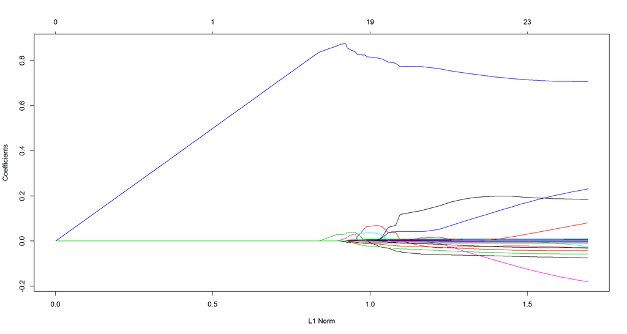

```r
lasso <- glmnet(x = X.train, y = y.train)
plot(lasso)
```

We will calculate a Lasso model with 10-fold cross-validation, which is the standard in glmnet. We will use the model with the largest regularisation parameter lambda whose prediction results lie within one standard error of the lambda that yields the minimum MSE (lambda.1se) in order to avoid overfitting.

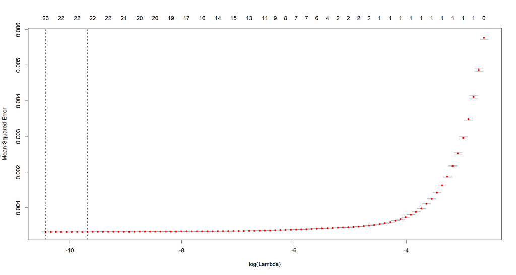

```r
cvlasso = cv.glmnet(x = X.train, y = y.train)
plot(cvlasso)
```

```r
cvlasso$lambda.1se
```

```
## [1] 6.228102e-05
```

```r
coef(cvlasso, s = "lambda.1se")
```

```
## 28 x 1 sparse Matrix of class "dgCMatrix"
##                              1
## (Intercept)       5.676264e-02
## Holiday           2.876519e-03
## temperature      -7.738894e-04
## humidity          6.783599e-03
## cloudCover        6.338877e-03
## pressure         -3.484074e-05
## Time              6.894755e-04
## mean_prev_day    -6.230832e-02
## mean_cons_.1380  -2.553808e-02
## mean_cons_.1410   .
## mean_cons_.1440   7.460912e-01
## mean_last3d_.0    .
## mean_last3d_.30   .
## mean_last3d_.60   1.858837e-01
## mean_last3d_.90   4.042870e-03
## mean_last3w_.0    .
## mean_last3w_.30   8.588535e-02
## mean_last3w_.60   .
## mean_last3w_.90  -4.245175e-02
## DoWMonday        -8.448840e-03
## DoWSaturday       4.410985e-03
## DoWSunday         9.743031e-03
## DoWThursday      -9.032196e-04
## DoWTuesday       -2.981703e-03
## DoWWednesday     -2.118200e-03
## TariffToU_Low    -1.891718e-02
## TariffToU_Normal -3.234018e-02
## TariffToU_High   -4.558091e-02
```

```r
length(coef(cvlasso, s = "lambda.1se")[which(coef(cvlasso, s = "lambda.1se") != 0)])
```

```
## [1] 23
```

The MSE - lambda curve is quite smooth and lambda.1se is very small. Thus, regularisation is not very noticeable and the model keeps 23 coefficients out of 28 (including the intercept). All of the variables dropped are engineered features.

```r
pred.lasso <- predict(cvlasso, newx = X.test, s = "lambda.1se")
rmse.lasso <- mean((pred.lasso - y.test)^2)^(1/2)
rmse.lasso
```

```
## [1] 0.01847996
```

```r
rmse.lasso/y.mean
```

```
## [1] 0.08719023
```

```r
pred.ToU.lasso <- predict(cvlasso, newx = X.ToU.test, s = "lambda.1se")
rmse.ToU.lasso <- mean((pred.ToU.lasso - y.ToU.test)^2)^(1/2)
rmse.ToU.lasso
```

```
## [1] 0.01976063
```

```r
rmse.ToU.lasso/y.ToU.mean
```

```
## [1] 0.1005601
```

The RMSE is nearly identical to that of OLS in the test data, both for the complete train dataset and considering only ToU data points. This means we have not achieved a significant improvement with this method.

#### Ridge

Now let us try improving the model using Ridge regularisation. This method favours keeping all predictors but shrinking their coefficients, effectively letting all variables in their model have a (reduced) effect on the prediction.

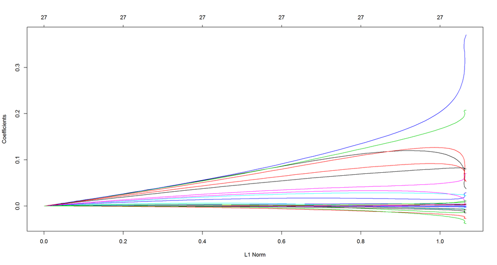

```r
ridge <- glmnet(x = X.train, y = y.train, alpha = 0)
plot(ridge)
```

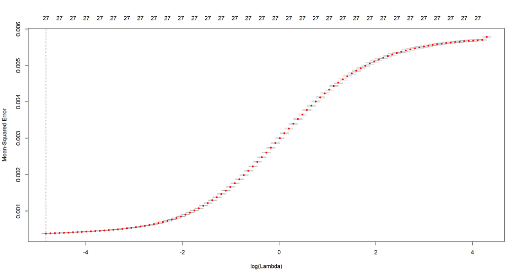

```r
cvridge = cv.glmnet(x = X.train, y = y.train, alpha = 0)
plot(cvridge)
```

```r
cvridge$lambda.1se
```

```
## [1] 0.008043903
```

```r
pred.ridge <- predict(cvridge, newx = X.test, s = "lambda.1se")
rmse.ridge <- mean((pred.ridge - y.test)^2)^(1/2)
rmse.ridge
```

```
## [1] 0.02062264
```

```r
rmse.ridge/y.mean
```

```
## [1] 0.09729959
```

```r
pred.ToU.ridge <- predict(cvridge, newx = X.ToU.test, s = "lambda.1se")
rmse.ToU.ridge <- mean((pred.ToU.ridge - y.ToU.test)^2)^(1/2)
rmse.ToU.ridge
```

```
## [1] 0.02125796
```

```r
rmse.ToU.ridge/y.ToU.mean
```

```
## [1] 0.1081799
```

RMSE in the test set is 1% higher than that for the OLS and Lasso models, so it seems we have not achieved any improvement neither.

## 4.2.4. Linear models with interactions

To improve our linear models we can add second-order interactions. We will remove the interactions of Holiday with the other variables because there are too few points with Holiday = 1 and some interactions cannot even be calculated (e.g. Holiday with some days of week).

### Ordinary least squares

```r
ols.int <- lm(mean_cons ~ .^2 - Holiday*. , data = subset(df2, select = -c(DateTime, Set, ToU), Set == "Train"))

pred.ols.int <- predict.lm(ols.int, newdata = subset(df2, Set == "Test", select = -c(Set,mean_cons)))
rmse.ols.int <- mean((pred.ols.int - subset(df2, Set == "Test")$mean_cons)^2)^(1/2)
rmse.ols.int/y.mean
```

```
## [1] 0.06577222
```

```r
pred.ToU.ols.int <- predict.lm(ols.int, newdata = df2[df2["Set"] == "Test" & df2["ToU"] == 1,])
rmse.ToU.ols.int <- mean((pred.ToU.ols.int - df2[df2["Set"] == "Test" & df2["ToU"] == 1, "mean_cons"])^2)^(1/2)
rmse.ToU.ols.int/y.ToU.mean
```

```
## [1] 0.08157227
```

```r
length(coef(ols.int))
```

```
## [1] 334
```

Note that this model has 334 coefficients (counting the intercept). This is a fairly large number that leads us to think Lasso regularisation can be more beneficial than in the simple linear model.

### Lasso

In order to use the glmnet functions for generalised linear regression we need to build the X train and test matrices (y does not change). We will use the model.matrix function to built the new matrices with interactions from the linear ones.

```r
X.train.int <- model.matrix(~ .^2 - Holiday*., as.data.frame(X.train))[,-1]
X.test.int <- model.matrix(~ .^2 - Holiday*., as.data.frame(X.test))[,-1]
X.ToU.test.int <- model.matrix(~ .^2 - Holiday*., as.data.frame(X.ToU.test))[,-1]
```

Now we can apply the lasso regularised regression with second-order interactions. Lasso regularisation has not really improved the OLS second-order interaction results.

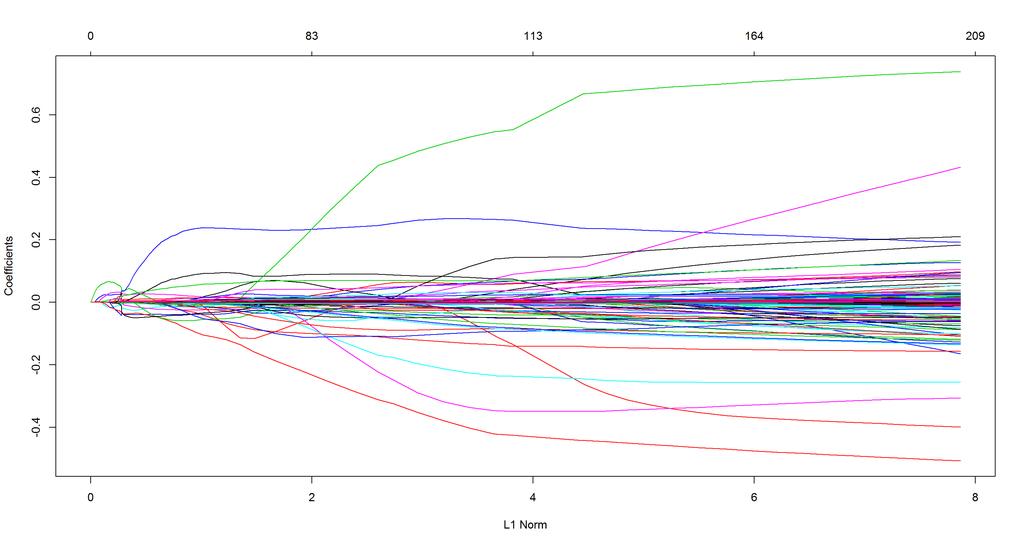

```r
lasso.int <- glmnet(x = X.train.int, y = y.train)

plot(lasso.int)
```

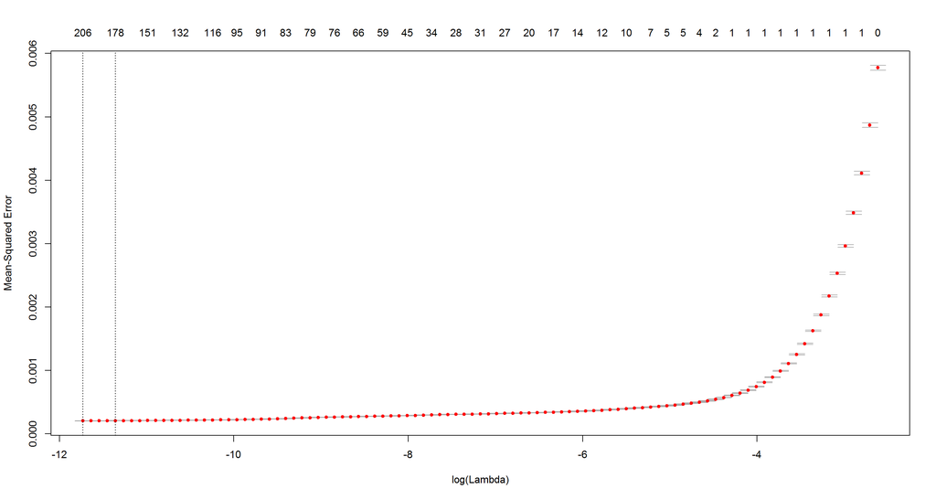

```r
cvlasso.int = cv.glmnet(x = X.train.int, y = y.train)
plot(cvlasso.int)
```

```r
length(coef(cvlasso.int, s = "lambda.1se")[which(coef(cvlasso.int, s = "lambda.1se") != 0)])
```

```
## [1] 179
```

```r
pred.lasso.int <- predict(cvlasso.int, newx = X.test.int, s = "lambda.1se")
rmse.lasso.int <- mean((pred.lasso.int - y.test)^2)^(1/2)
rmse.lasso.int/y.mean
```

```
## [1] 0.07166825
```

```r
pred.ToU.lasso <- predict(cvlasso, newx = X.ToU.test, s = "lambda.1se")
rmse.ToU.lasso <- mean((pred.ToU.lasso - y.ToU.test)^2)^(1/2)
rmse.ToU.lasso/y.ToU.mean
```

```
## [1] 0.1005601
```

### Ridge

Ridge regression did not fare well with main effects only but we will test with second-order interactions for completeness.

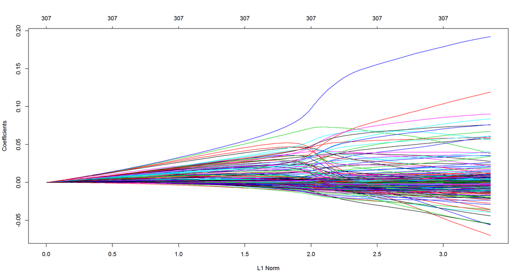

```r
ridge.int <- glmnet(x = X.train.int, y = y.train, alpha = 0)
plot(ridge.int)
```

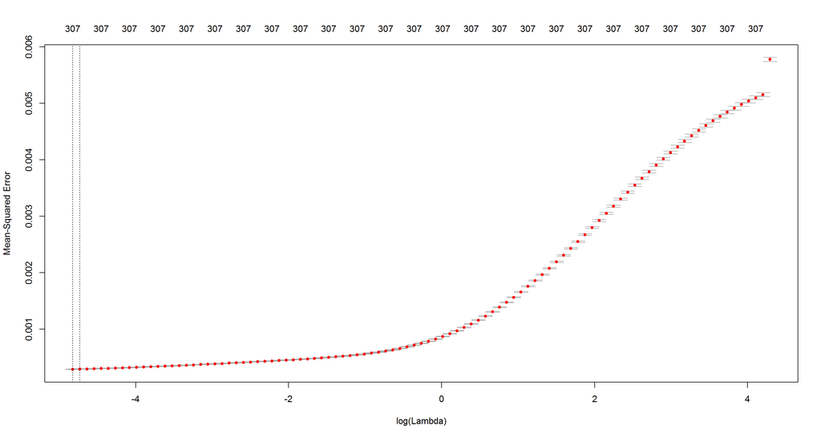

```r
cvridge.int = cv.glmnet(x = X.train.int, y = y.train, alpha = 0)
plot(cvridge.int)
```

```r
pred.ridge.int <- predict(cvridge.int, newx = X.test.int, s = "lambda.1se")
rmse.ridge.int <- mean((pred.ridge.int - y.test)^2)^(1/2)
rmse.ridge.int/y.mean
```

```
## [1] 0.08527595
```

```r
pred.ToU.ridge.int <- predict(cvridge.int, newx = X.ToU.test.int, s = "lambda.1se")
rmse.ToU.ridge.int <- mean((pred.ToU.ridge.int - y.ToU.test)^2)^(1/2)
rmse.ToU.ridge.int/y.ToU.mean
```

```
## [1] 0.100377
```

Again, ridge regularisation does not improve OLS results with a normalised RMSE over 1% higher.

## 4.2.5. Model comparison

We need to import some libraries to treat and plot the data (scales is needed to use datetime scales in ggplot). We also set the locale to English to display the names of the days of the week in English.

```r
library(ggplot2)
library(gridExtra)
library(zoo)
library(xts)
library(scales)
library(reshape2)
Sys.setlocale("LC_TIME", "English")
```

```
## [1] "English_United States.1252"
```

Generating the charts and tables in this section will be much easier if we build a dataframe with the true and predicted values and we separate it in standard and ToU tariffs. In this section we will use the OLS model with the tariff value considered as categorical.

```r
predictions <- cbind.data.frame(df2.test[,c("DateTime","Tariff_value","ToU")], y.test, pred.ols, pred.ols2, pred.lasso, pred.ridge,
                                pred.ols.int, pred.lasso.int, pred.ridge.int)
colnames(predictions) <- c("DateTime","Tariff_value","ToU","y.true","y.ols","y.ols2","y.lasso","y.ridge","y.ols.int",
                           "y.lasso.int","y.ridge.int")
predictions$DateTime <- as.POSIXct(predictions$DateTime, tz= "", format = "%Y-%m-%d %H:%M:%S")
head(predictions)
```

```
##                  DateTime Tariff_value ToU     y.true      y.ols
## 45517 2013-10-01 00:00:00       11.760   1 0.11460476 0.10550168
## 45518 2013-10-01 00:00:00       14.228   0 0.14225060 0.13538148
## 45519 2013-10-01 00:30:00       11.760   1 0.10389724 0.09550378
## 45520 2013-10-01 00:30:00       14.228   0 0.12583101 0.12250577
## 45521 2013-10-01 01:00:00       11.760   1 0.09918839 0.09173709
## 45522 2013-10-01 01:00:00       14.228   0 0.11410833 0.11095572
##           y.ols2    y.lasso    y.ridge y.ols.int y.lasso.int y.ridge.int
## 45517 0.10468932 0.10481429 0.10233335 0.1144934  0.11275056  0.10818880
## 45518 0.13568262 0.13585257 0.12675461 0.1451352  0.14337202  0.13293289
## 45519 0.09473515 0.09550692 0.09627196 0.1040968  0.10343613  0.10213148
## 45520 0.12279111 0.12294181 0.11615093 0.1301547  0.12949111  0.12257726
## 45521 0.09088035 0.09202302 0.09327120 0.1011128  0.09949066  0.09937373
## 45522 0.11124744 0.11131344 0.10761592 0.1170899  0.11672475  0.11407740
```

```r
predictions.std <- predictions[predictions["ToU"] == 0,]
predictions.ToU <- predictions[predictions["ToU"] == 1,]
```

Before plotting the predictions we will calculate the errors for all models and compare them.

$y.ols$ refers to the OLS model that treats the Tariff variable as continuous while ols2 is the model with Tariff as a categorical variable. We will call them OLS_num and OLS_factors respectively. The long format dataframes are generated to plot error histograms.

```r
errors.std <- predictions.std
errors.std[,'y.ols'] <- (predictions.std[,'y.true'] - predictions.std[,'y.ols'])/predictions.std[,'y.true']
errors.std[,'y.ols2'] <- (predictions.std[,'y.true'] - predictions.std[,'y.ols2'])/predictions.std[,'y.true']
errors.std[,'y.lasso'] <- (predictions.std[,'y.true'] - predictions.std[,'y.lasso'])/predictions.std[,'y.true']
errors.std[,'y.ridge'] <- (predictions.std[,'y.true'] - predictions.std[,'y.ridge'])/predictions.std[,'y.true']
errors.std[,'y.ols.int'] <- (predictions.std[,'y.true'] - predictions.std[,'y.ols.int'])/predictions.std[,'y.true']
errors.std[,'y.lasso.int'] <- (predictions.std[,'y.true'] - predictions.std[,'y.lasso.int'])/predictions.std[,'y.true']
errors.std[,'y.ridge.int'] <- (predictions.std[,'y.true'] - predictions.std[,'y.ridge.int'])/predictions.std[,'y.true']

errors.ToU <- predictions.ToU
errors.ToU[,'y.ols'] <- (predictions.ToU[,'y.true'] - predictions.ToU[,'y.ols'])/predictions.ToU[,'y.true']
errors.ToU[,'y.ols2'] <- (predictions.ToU[,'y.true'] - predictions.ToU[,'y.ols2'])/predictions.ToU[,'y.true']
errors.ToU[,'y.lasso'] <- (predictions.ToU[,'y.true'] - predictions.ToU[,'y.lasso'])/predictions.ToU[,'y.true']
errors.ToU[,'y.ridge'] <- (predictions.ToU[,'y.true'] - predictions.ToU[,'y.ridge'])/predictions.ToU[,'y.true']
errors.ToU[,'y.ols.int'] <- (predictions.ToU[,'y.true'] - predictions.ToU[,'y.ols.int'])/predictions.ToU[,'y.true']
errors.ToU[,'y.lasso.int'] <- (predictions.ToU[,'y.true'] - predictions.ToU[,'y.lasso.int'])/predictions.ToU[,'y.true']
errors.ToU[,'y.ridge.int'] <- (predictions.ToU[,'y.true'] - predictions.ToU[,'y.ridge.int'])/predictions.ToU[,'y.true']

errors.std.long <- melt(errors.std[,c("y.ols", "y.ols2","y.lasso","y.ridge","y.ols.int","y.lasso.int","y.ridge.int")])
errors.ToU.long <- melt(errors.ToU[,c("y.ols", "y.ols2","y.lasso","y.ridge","y.ols.int","y.lasso.int","y.ridge.int")])
summary(errors.std)
```

```
##     DateTime                    Tariff_value        ToU
##  Min.   :2013-10-01 00:00:00   Min.   :14.23   Min.   :0
##  1st Qu.:2013-11-07 12:00:00   1st Qu.:14.23   1st Qu.:0
##  Median :2013-12-15 00:00:00   Median :14.23   Median :0
##  Mean   :2013-12-15 00:00:00   Mean   :14.23   Mean   :0
##  3rd Qu.:2014-01-21 12:00:00   3rd Qu.:14.23   3rd Qu.:0
##  Max.   :2014-02-28 00:00:00   Max.   :14.23   Max.   :0
##      y.true            y.ols                y.ols2
##  Min.   :0.09502   Min.   :-0.3974707   Min.   :-0.3965124
##  1st Qu.:0.17033   1st Qu.:-0.0299765   1st Qu.:-0.0296200
##  Median :0.22587   Median : 0.0071472   Median : 0.0075579
##  Mean   :0.23190   Mean   :-0.0009475   Mean   :-0.0007816
##  3rd Qu.:0.28403   3rd Qu.: 0.0405773   3rd Qu.: 0.0405038
##  Max.   :0.41720   Max.   : 0.2765063   Max.   : 0.2763691
##     y.lasso             y.ridge            y.ols.int
##  Min.   :-0.409104   Min.   :-0.467987   Min.   :-0.358448
##  1st Qu.:-0.029181   1st Qu.:-0.053531   1st Qu.:-0.029567
##  Median : 0.005755   Median : 0.009365   Median :-0.001138
##  Mean   :-0.001710   Mean   :-0.006253   Mean   :-0.002111
##  3rd Qu.: 0.039171   3rd Qu.: 0.053538   3rd Qu.: 0.026742
##  Max.   : 0.296775   Max.   : 0.274127   Max.   : 0.302436
##   y.lasso.int         y.ridge.int
##  Min.   :-0.309497   Min.   :-0.379914
##  1st Qu.:-0.023907   1st Qu.:-0.043482
##  Median : 0.004217   Median : 0.003992
##  Mean   : 0.003322   Mean   :-0.000182
##  3rd Qu.: 0.034441   3rd Qu.: 0.046254
##  Max.   : 0.303227   Max.   : 0.308537
```

```r
summary(errors.ToU)
```

```
##     DateTime                    Tariff_value        ToU
##  Min.   :2013-10-01 00:00:00   Min.   : 3.99   Min.   :1
##  1st Qu.:2013-10-23 23:52:30   1st Qu.:11.76   1st Qu.:1
##  Median :2013-11-15 23:45:00   Median :11.76   Median :1
##  Mean   :2013-11-15 23:45:00   Mean   :13.60   Mean   :1
##  3rd Qu.:2013-12-08 23:37:30   3rd Qu.:11.76   3rd Qu.:1
##  Max.   :2013-12-31 23:30:00   Max.   :67.20   Max.   :1
##      y.true            y.ols              y.ols2
##  Min.   :0.08542   Min.   :-0.48235   Min.   :-0.474040
##  1st Qu.:0.14406   1st Qu.:-0.03040   1st Qu.:-0.034426
##  Median :0.20478   Median : 0.02089   Median : 0.019933
##  Mean   :0.20825   Mean   : 0.01062   Mean   : 0.007691
##  3rd Qu.:0.26382   3rd Qu.: 0.06464   3rd Qu.: 0.063971
##  Max.   :0.41759   Max.   : 0.30462   Max.   : 0.277051
##     y.lasso             y.ridge             y.ols.int
##  Min.   :-0.505053   Min.   :-0.4874834   Min.   :-0.41963
##  1st Qu.:-0.037504   1st Qu.:-0.0741771   1st Qu.:-0.01740
##  Median : 0.016937   Median : 0.0005781   Median : 0.02371
##  Mean   : 0.003878   Mean   :-0.0193619   Mean   : 0.02138
##  3rd Qu.: 0.059549   3rd Qu.: 0.0540389   3rd Qu.: 0.05890
##  Max.   : 0.304118   Max.   : 0.2671973   Max.   : 0.31055
##   y.lasso.int        y.ridge.int
##  Min.   :-0.35452   Min.   :-0.416223
##  1st Qu.:-0.01867   1st Qu.:-0.046937
##  Median : 0.02532   Median : 0.012409
##  Mean   : 0.02101   Mean   : 0.004862
##  3rd Qu.: 0.06341   3rd Qu.: 0.062601
##  Max.   : 0.29090   Max.   : 0.292052
```

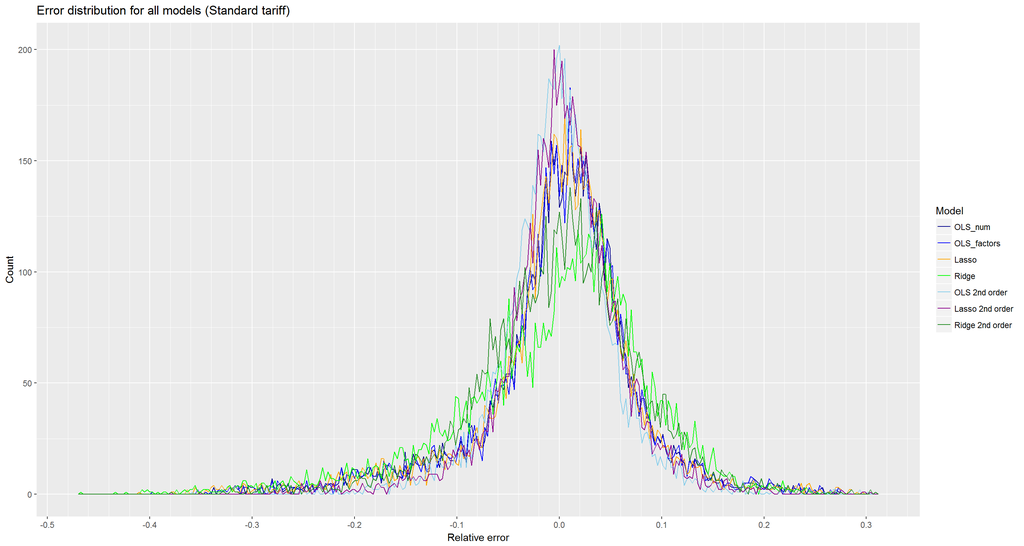

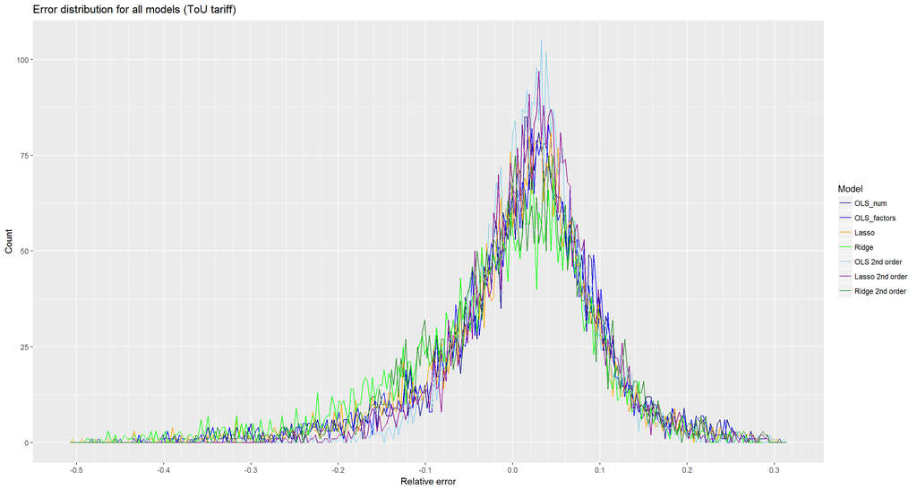

Now we will compare the response variable (mean aggregate consumption) true values with the predicted values of the OLS, Lasso and Ridge models and their second-order counterparts. We will first built an xts object with the predicted values for ease of use and then create some relevant plots.

From now on, we will just consider the the OLS model with Tariff as categorical (OLS_factors in this chart), but before that let us just check the difference in prediction for a week of test data. The prediction is quite similar with OLS_factors faring slightly better on this Sunday. As accuracy is just marginally better (in terms of RMSE and maximum and minimum errors), the main reason to choose this model is that the predicted influence of the Tariff on the consumption is better computed when treated as categorical.

```r
X.pred.std <- xts(predictions.std[,c("y.true","y.ols","y.ols2","y.lasso","y.ridge","y.ols.int",
                                     "y.lasso.int","y.ridge.int")], order.by = predictions.std[,"DateTime"])
X.pred.ToU <- xts(predictions.ToU[,c("Tariff_value","y.true","y.ols","y.ols2","y.lasso","y.ridge","y.ols.int",
                                     "y.lasso.int","y.ridge.int")], order.by = predictions.ToU[,"DateTime"])
head(X.pred.std)
```

```
##                         y.true      y.ols     y.ols2    y.lasso    y.ridge
## 2013-10-01 00:00:00 0.14225060 0.13538148 0.13568262 0.13585257 0.12675461
## 2013-10-01 00:30:00 0.12583101 0.12250577 0.12279111 0.12294181 0.11615093
## 2013-10-01 01:00:00 0.11410833 0.11095572 0.11124744 0.11131344 0.10761592
## 2013-10-01 01:30:00 0.10816061 0.10282146 0.10305961 0.10343286 0.10239250
## 2013-10-01 02:00:00 0.10085604 0.09816376 0.09840770 0.09909362 0.10005191
## 2013-10-01 02:30:00 0.09920799 0.09753165 0.09773711 0.09823140 0.09944048
##                     y.ols.int y.lasso.int y.ridge.int
## 2013-10-01 00:00:00 0.1451352   0.1433720   0.1329329
## 2013-10-01 00:30:00 0.1301547   0.1294911   0.1225773
## 2013-10-01 01:00:00 0.1170899   0.1167247   0.1140774
## 2013-10-01 01:30:00 0.1076480   0.1077190   0.1085744
## 2013-10-01 02:00:00 0.1031344   0.1028612   0.1059022
## 2013-10-01 02:30:00 0.1025620   0.1016086   0.1050906
```

```r
head(X.pred.ToU)
```

```
##                     Tariff_value     y.true      y.ols     y.ols2
## 2013-10-01 00:00:00        11.76 0.11460476 0.10550168 0.10468932
## 2013-10-01 00:30:00        11.76 0.10389724 0.09550378 0.09473515
## 2013-10-01 01:00:00        11.76 0.09918839 0.09173709 0.09088035
## 2013-10-01 01:30:00        11.76 0.09490961 0.08866321 0.08775733
## 2013-10-01 02:00:00        11.76 0.09639391 0.08609723 0.08521766
## 2013-10-01 02:30:00        11.76 0.09105614 0.08298780 0.08212135
##                        y.lasso    y.ridge  y.ols.int y.lasso.int
## 2013-10-01 00:00:00 0.10481429 0.10233335 0.11449343  0.11275056
## 2013-10-01 00:30:00 0.09550692 0.09627196 0.10409680  0.10343613
## 2013-10-01 01:00:00 0.09202302 0.09327120 0.10111279  0.09949066
## 2013-10-01 01:30:00 0.08816893 0.09064896 0.09812590  0.09553597
## 2013-10-01 02:00:00 0.08565723 0.08892768 0.09494911  0.09251957
## 2013-10-01 02:30:00 0.08315039 0.08777921 0.09167387  0.08976865
##                     y.ridge.int
## 2013-10-01 00:00:00  0.10818880
## 2013-10-01 00:30:00  0.10213148
## 2013-10-01 01:00:00  0.09937373
## 2013-10-01 01:30:00  0.09682669
## 2013-10-01 02:00:00  0.09502762
## 2013-10-01 02:30:00  0.09370998
```

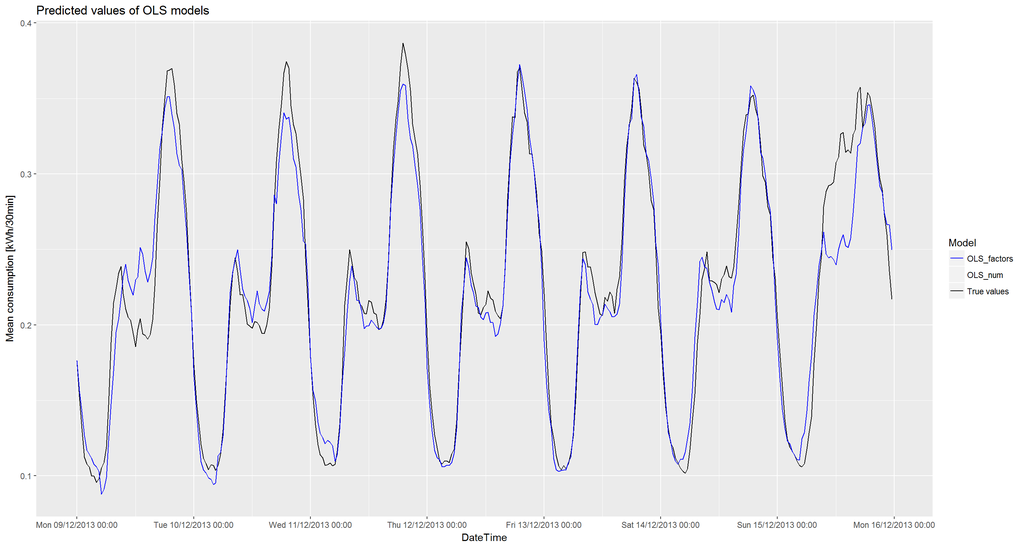

The next plot compares all linear models and the true values of the response variable for ToU data points. It looks like the models follow the cyclic nature of the true values but there is too much data in the plot to draw any conclusion.

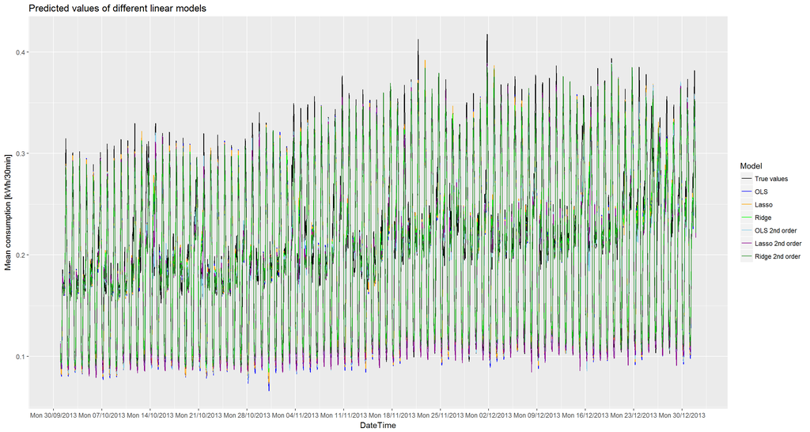

Therefore, we will plot only one week intervals. We will add the tariff plot for the same interval. Then, we will plot another two weeks of standard tariff data.

##### ToU tariff

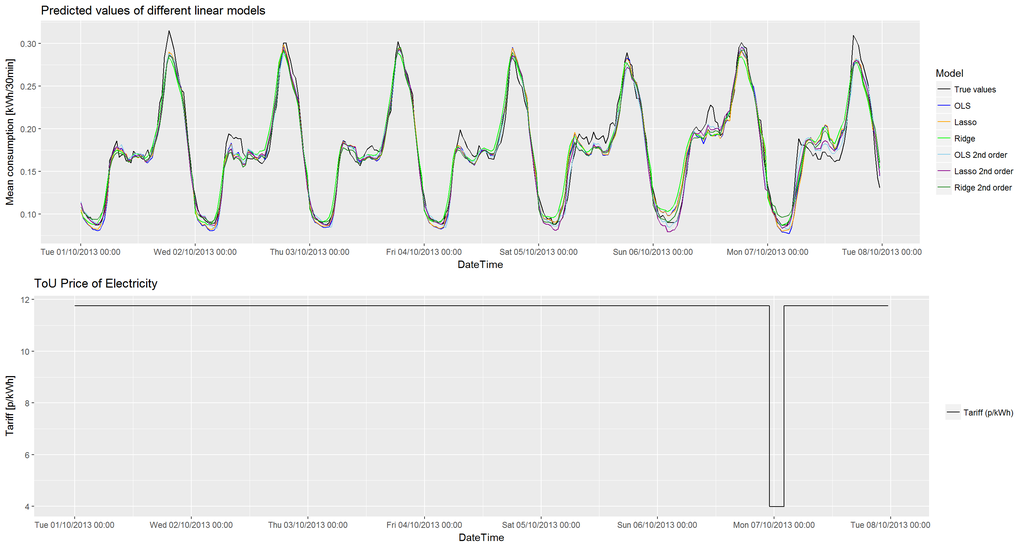

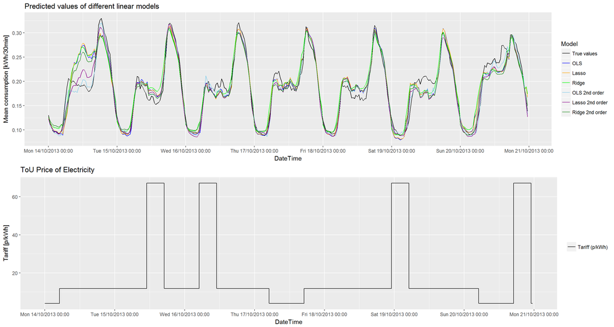

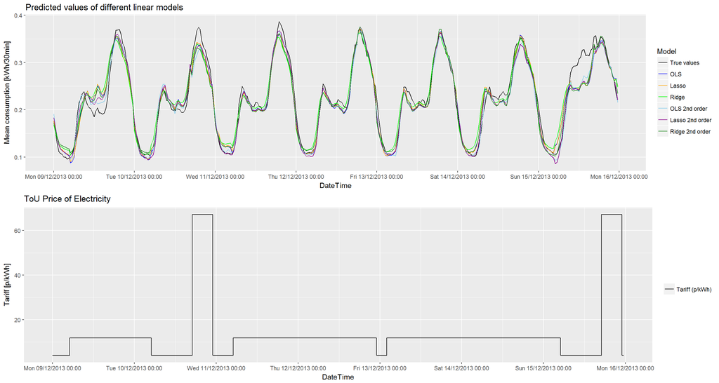

##### Standard tariff

This is first week of predicted data.

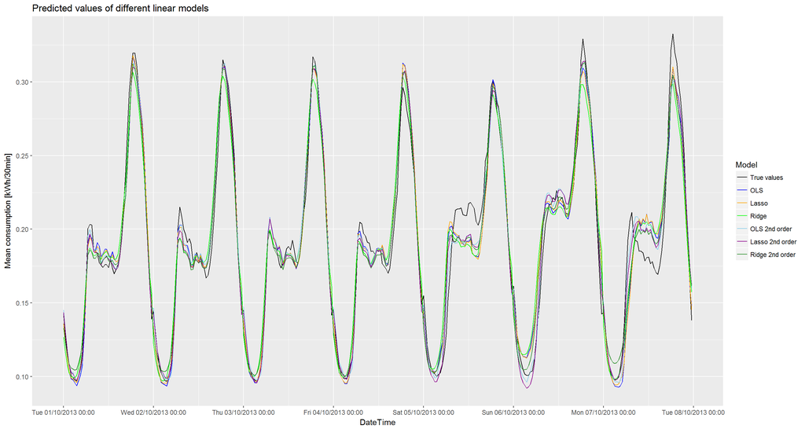

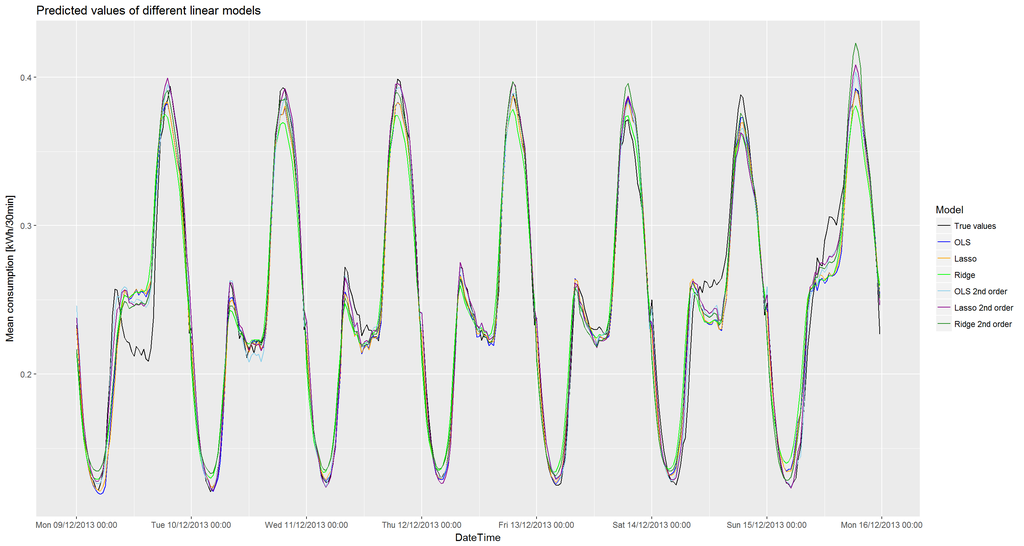

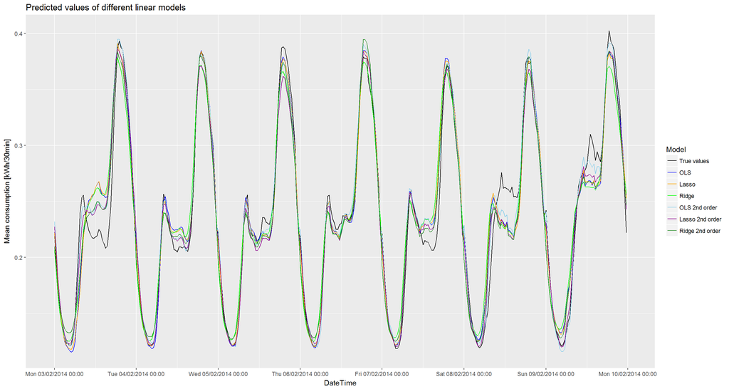

In general all models capture the cyclic nature of the consumption data. However, they do not follow well the actual increase of consumption values in the late morning and afternoon hours of Sundays and then overestimate the same period on Mondays in two of the weeks displayed here. However, this phenomenon is not always present, as in the first week of the test dataset. This is probably due to the influence of the features constructed with the consumption of the previous day. This effect has been mitigated by including second-order interactions in the OLS and Lasso models, but it is noticeable.

Finally, the next plot shows the daily averaged data of the whole test dataset for standard tariff users. This is a way of checking whether the model has capture the data seasonality (higher consumption in winter than in summer as we saw in the exploratory data analysis). It looks like all models follow the general trend quite well.

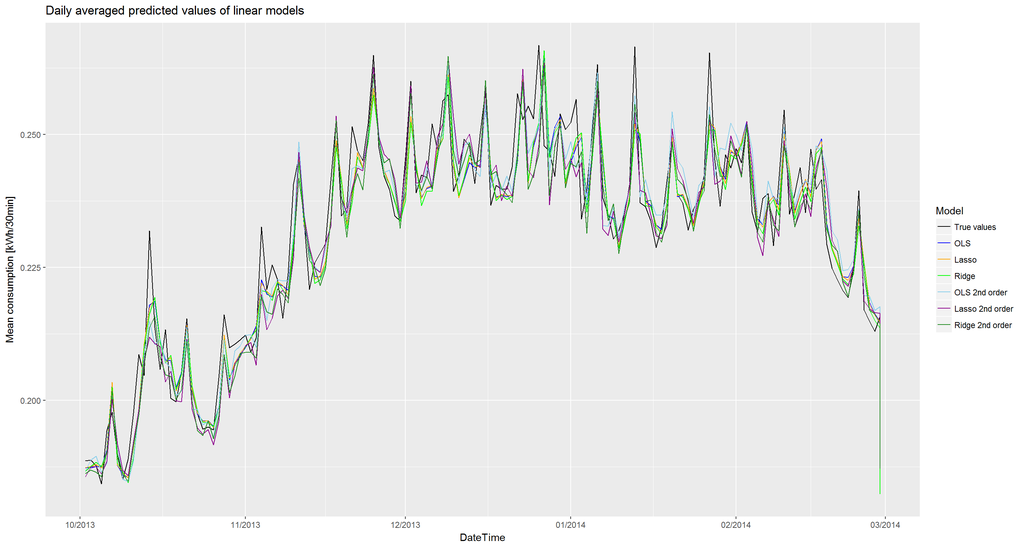

## 4.2.6. Conclusions

In terms of machine learning, linear feature modelling has proven to give a good fit to our test data, following its different cyclic trends (daily, weekly, seasonal). OLS with second-order interactions has proven the best model with a normalised RMSE of 6.5%. Therefore, it is not necessary to explore more complex feature models to try to improve the fit. The inclusion of second-order interactions have improved the prediction of the aggregate demand on some Sunday late mornings and early afternoons, where the actual demand presents a higher variability than in other days (sometimes higher and sometimes lower). However, there is still an opportunity to improve the model during these periods.

In Section 4.3 we will fit the data using a specific time series model, namely exponential smoothing. In any case, feature modelling has proven effective. More complex feature models are popular in the electricity demand prediction literature and should have been explored if linear models had not given us adequate results. The most widely used of these are different variants of neural networks, such as Artifical Neural Networks (ANN) [4]. Another interesting approach is a time series forecasting based on pattern sequence similarity (PSF), which basically labels each 24-hour segment with clustering methods, then looks for equal sequences in historical data and predicts the demand of the following days by averaging all previous days in the dataset which follow the identified sequence.